# Reproducible Research P1

Phil Burdi (pburdi@gmail.com)

Sunday, January 18, 2015

Load up the libraries needed for this assignment.

Download the data file and after we downloaded the file, we unzipped manual using winwar. (download.file(“https://d396qusza40orc.cloudfront.net/repdata%2Fdata%2Factivity.zip”, “c5p1.zip”))

Read the data file and setup the environment.

```r
ACT1 <- read.csv("activity.csv", sep = ",", header = TRUE)
ACT2 <- na.omit(ACT1)
ACT2 <- group_by(ACT2, date)
summary(ACT2)
```

```
##      steps                date          interval
##  Min.   :  0.00   2012-10-02:  288   Min.   :   0.0
##  1st Qu.:  0.00   2012-10-03:  288   1st Qu.: 588.8
##  Median :  0.00   2012-10-04:  288   Median :1177.5
##  Mean   : 37.38   2012-10-05:  288   Mean   :1177.5
##  3rd Qu.: 12.00   2012-10-06:  288   3rd Qu.:1766.2
##  Max.   :806.00   2012-10-07:  288   Max.   :2355.0
##                   (Other)   :13536
```

We are going to summarize to get the median and mean per day. For question “What is mean total number of steps taken per day?”

```r
ACT3 <- summarize(ACT2, total_steps = sum(steps), mean_steps = mean(steps), median_steps = median(steps))
summary(ACT3$total_steps)
```

```
##    Min. 1st Qu.  Median    Mean 3rd Qu.    Max.
##      41    8841   10760   10770   13290   21190
```

Now produce the histogram to show the total steps during all the intervals.

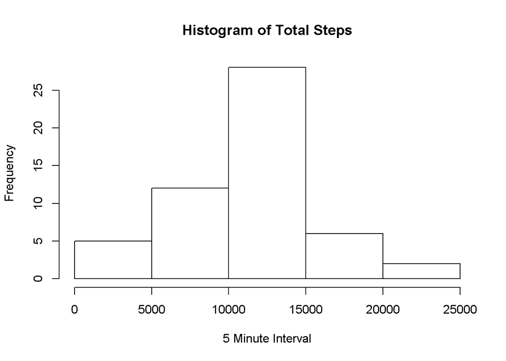

```r
hist(ACT3$total_steps, xlab="5 Minute Interval", main="Histogram of Total Steps")
```

To answer the question “What is the average daily activity pattern?” we applied the mean to the steps and to the interval`.

```r
ACT4 <- tapply(ACT2$steps, ACT2$interval, mean)
```

Now plot the result of the average number of steps taken.

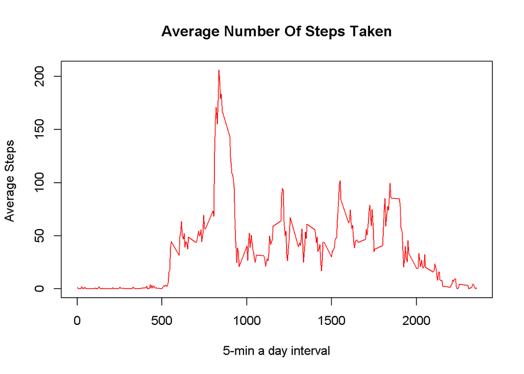

```r
plot(row.names(ACT4), ACT4, type = "l", xlab = "5-min a day interval", ylab = "Average Steps ", main = "Average Number Of Steps Taken", col = "red")
```

Now we input the missing values and see how it skews the results - we check the max interval and the number of rows

```r
Max_Interval <- which.max(ACT4)
names(Max_Interval)
```

```
## [1] "835"
```

```r
na_cases <- ACT1[!complete.cases(ACT1),]
nrow(na_cases)
```

```
## [1] 2304
```

Lets assign some data to the NAs

```r
ACT1_1 <- ACT1
ACT1_1[is.na(ACT1_1)] <- 1
```

Plot the result and check against the previous histogram

```r
ACT2_1 <- group_by(ACT1_1, date)
ACT3_1 <- summarize(ACT2_1, total_steps = sum(steps), mean_steps = mean(steps), median_steps = median(steps))
summary(ACT3_1$total_steps)
```

```
##    Min. 1st Qu.  Median    Mean 3rd Qu.    Max.
##      41    6778   10400    9392   12810   21190
```

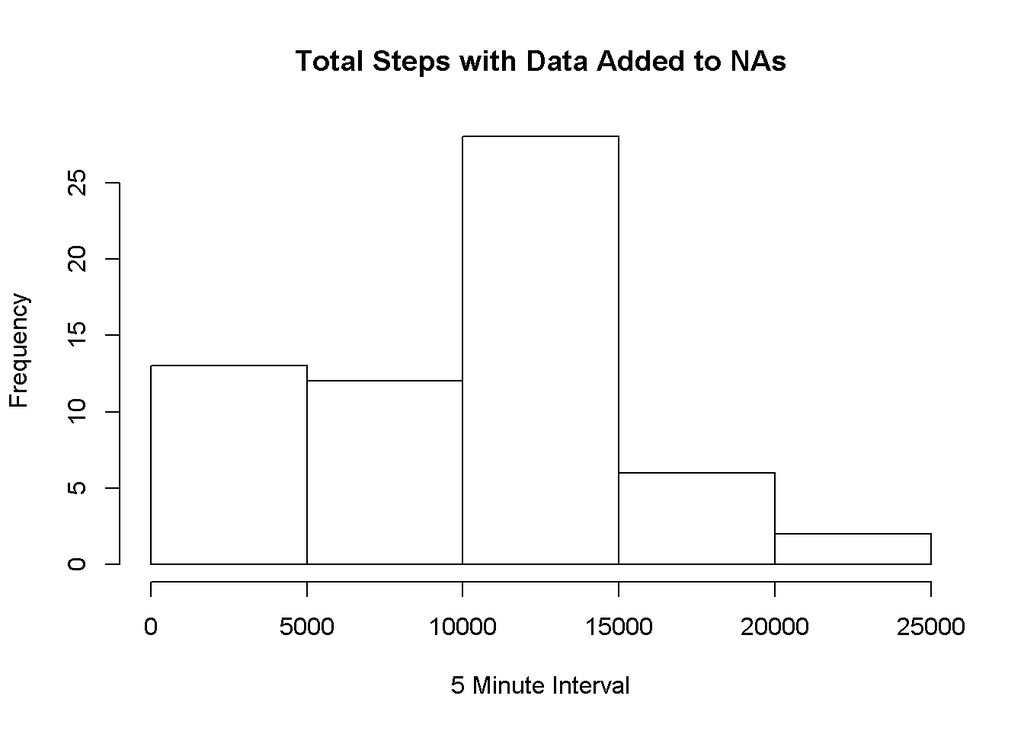

```r
hist(ACT3_1$total_steps, xlab="5 Minute Interval", main="Total Steps with Data Added to NAs")
```

Also, the question “What is the impact of imputing missing data on the estimates of the total daily number of steps?” It skews the lower end of the frequency.

Looking at the final question “Are there differences in activity patterns between weekdays and weekends?” we will setup the data-sets to identify the weekday and weekend patterns

```r
ACT2_1$date <- as.Date(ACT2_1$date, "%Y-%m-%d")
ACT2_1$day <- weekdays(ACT2_1$date)
ACT2_1$day_type <- c("weekday")
for (w in 1:nrow(ACT2_1)){
   if (ACT2_1$day[w] == "Saturday" || ACT2_1$day[w] == "Sunday"){
     ACT2_1$day_type[w] <- "weekend"
   }
}
ACT2_2 <- aggregate(steps ~ interval+day_type, ACT2_1, mean)
```

Now lets examine the data-set in a plot.

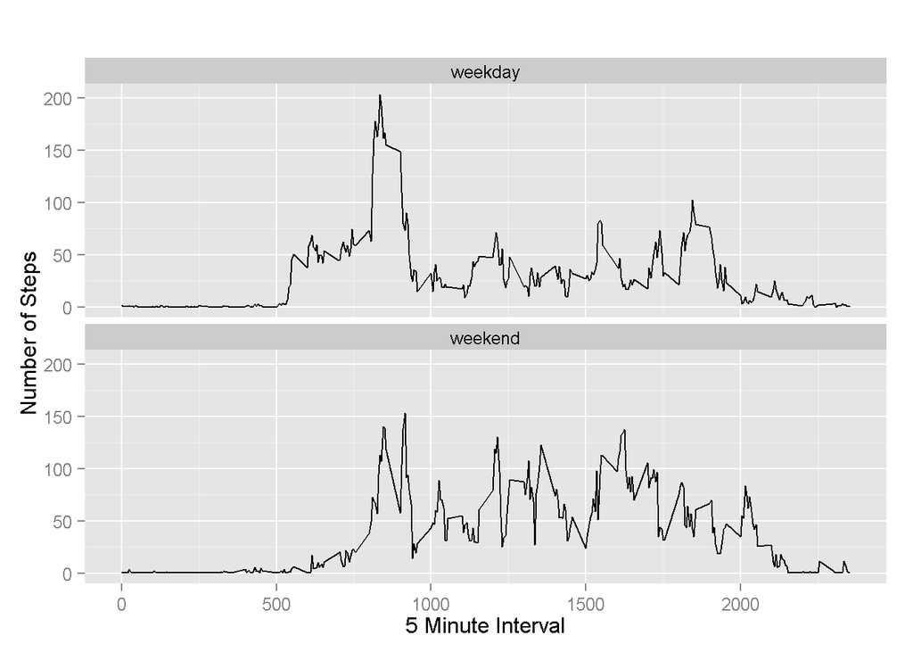

```r
qplot(interval, steps, data=ACT2_2, geom=c("line"), xlab="5 Minute Interval", ylab="Number of Steps", main="") + facet_wrap(~ day_type, ncol=1)
```

As shown the data for the weekday plot indicates a high frequency of activity in the morning and tapers off significantly around 10 AM - the weekend plot indicates a fairly consistent pattern from morning to mid-afternoon.

Thank you for reading - end of line…